# Credit Card Default

ISLR packages provide several datasets. The description of datasets are available here: http://cran.r-project.org/web/packages/ISLR/ISLR.pdf

```r
rm(list = ls())     # clear the workspace
library(ISLR)       # load ISLR data package
library(tidyverse)
library(ggplot2)
```

# 1 Data Preparation

Examine the dataset. It contains four variables, `default`, `student`,`balance`, and `income`.

```r
Default<-as_tibble(Default)
Default
```

| default | student | balance | income |
| --- | --- | --- | --- |
| No | No | 729.5264952 | 44361.625 |
| No | Yes | 817.1804066 | 12106.135 |
| No | No | 1073.5491640 | 31767.139 |
| No | No | 529.2506047 | 35704.494 |
| No | No | 785.6558829 | 38463.496 |
| No | Yes | 919.5885305 | 7491.559 |
| No | No | 825.5133305 | 24905.227 |
| No | Yes | 808.6675043 | 17600.451 |
| No | No | 1161.0578540 | 37468.529 |
| No | No | 0.0000000 | 29275.268 |

[output cut: 990 more lines]

```r
glimpse(Default)
```

```
Rows: 10,000
Columns: 4
$ default <fct> No, No, No, No, No, No, No, No, No, No, No, No, No, No, No, No, No, No, No, No, No, No, No, No, No, No, No, No, No, No, No, No, No, No, No, No, No, No, No, No, No, No, No, No, No, No,~
$ student <fct> No, Yes, No, No, No, Yes, No, Yes, No, No, Yes, Yes, No, No, No, No, No, Yes, No, No, No, No, No, No, No, No, No, No, No, Yes, No, Yes, Yes, No, Yes, Yes, No, No, No, No, No, No, No, ~
$ balance <dbl> 729.5265, 817.1804, 1073.5492, 529.2506, 785.6559, 919.5885, 825.5133, 808.6675, 1161.0579, 0.0000, 0.0000, 1220.5838, 237.0451, 606.7423, 1112.9684, 286.2326, 0.0000, 527.5402, 485.9~
$ income  <dbl> 44361.625, 12106.135, 31767.139, 35704.494, 38463.496, 7491.559, 24905.227, 17600.451, 37468.529, 29275.268, 21871.073, 13268.562, 28251.695, 44994.556, 23810.174, 45042.413, 50265.31~
```

```r
head(Default) # show the first six rows
```

| default | student | balance | income |
| --- | --- | --- | --- |
| No | No | 729.5265 | 44361.625 |
| No | Yes | 817.1804 | 12106.135 |
| No | No | 1073.5492 | 31767.139 |
| No | No | 529.2506 | 35704.494 |
| No | No | 785.6559 | 38463.496 |
| No | Yes | 919.5885 | 7491.559 |

```r
tail(Default) # show the last six rows
```

| default | student | balance | income |
| --- | --- | --- | --- |
| No | Yes | 172.4130 | 14955.94 |
| No | No | 711.5550 | 52992.38 |
| No | No | 757.9629 | 19660.72 |
| No | No | 845.4120 | 58636.16 |
| No | No | 1569.0091 | 36669.11 |
| No | Yes | 200.9222 | 16862.95 |

```r
names(Default)      # variable names
```

```
[1] "default" "student" "balance" "income"
```

```r
nrow(Default)       # the number of rows
```

```
[1] 10000
```

```r
ncol(Default)       # the number of columns
```

```
[1] 4
```

```r
summary(Default)    # basic summary statistics of the variables in Default dataset (default, student, balance, income)
```

```
 default    student       balance           income
 No :9667   No :7056   Min.   :   0.0   Min.   :  772
 Yes: 333   Yes:2944   1st Qu.: 481.7   1st Qu.:21340
                       Median : 823.6   Median :34553
                       Mean   : 835.4   Mean   :33517
                       3rd Qu.:1166.3   3rd Qu.:43808
                       Max.   :2654.3   Max.   :73554
```

```r
# frequency table
summary(Default$default)   # summary of default variable
```

```
  No  Yes
9667  333
```

```r
table(Default$default)     # contingency table: frequency of each case (yes/no) in default variable
```

```
  No  Yes
9667  333
```

```r
table(Default$student)     # contingency table: frequency of each case (yes/no) in student variable
```

```
  No  Yes
7056 2944
```

```r
table(Default$default, Default$student)  # cross-tabulation
```

```
        No  Yes
  No  6850 2817
  Yes  206  127
```

# 2 Data Visualization

## 2.1 Bar chart

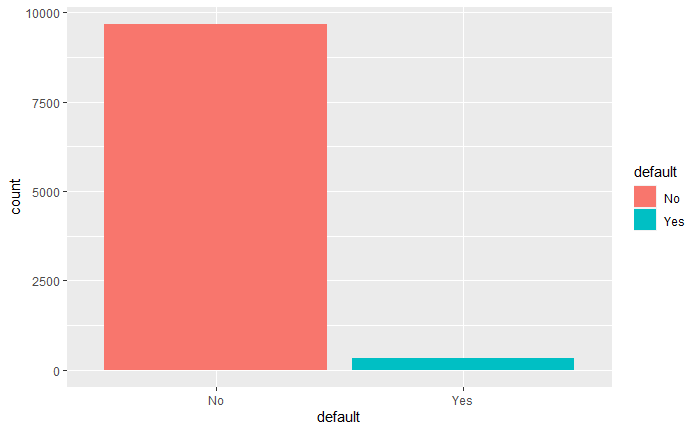

```r
Default %>%
  ggplot(aes(x=default,fill=default)) +
  geom_bar()
```

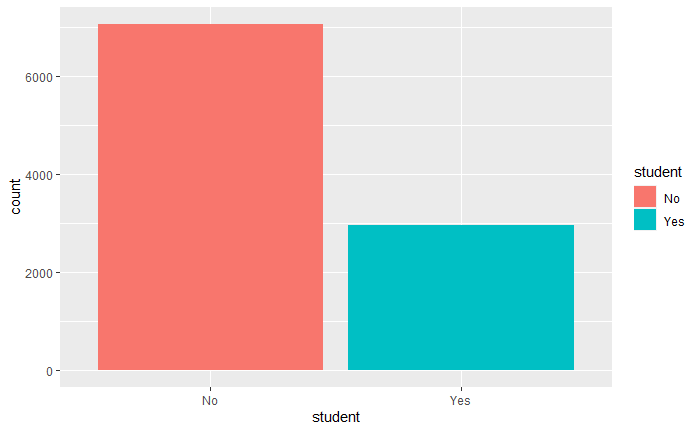

```r
Default %>%
  ggplot(aes(x=student,fill=student)) +
  geom_bar()
```

## 2.2 Histograms

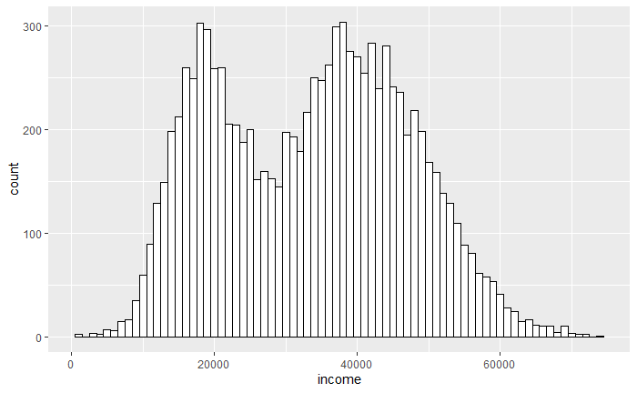

```r
Default %>%
  ggplot(aes(x=income)) +
  geom_histogram(binwidth=1000, colour="black",fill="white")
```

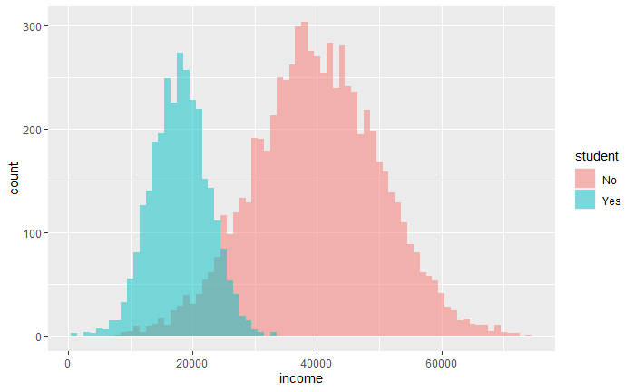

```r
Default %>%
  ggplot(aes(x=income,fill=student)) +
  geom_histogram(binwidth=1000,alpha=.5,position="identity")
```

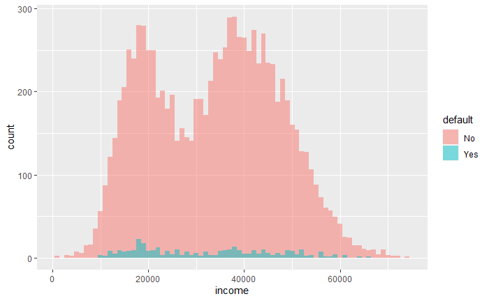

```r
Default %>%
  ggplot(aes(x=income,fill=default)) +
  geom_histogram(binwidth=1000,alpha=.5,position="identity")
```

## 2.3 Boxplots

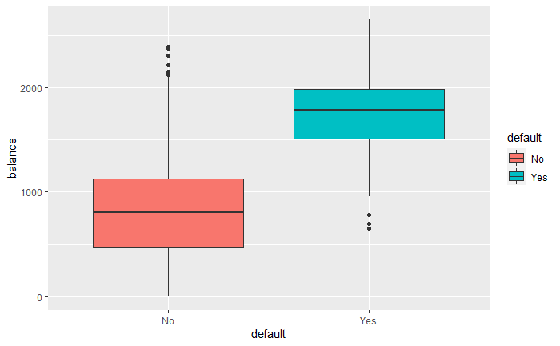

```r
ggplot(Default,aes(x=default,y=balance,fill=default))+geom_boxplot()
```

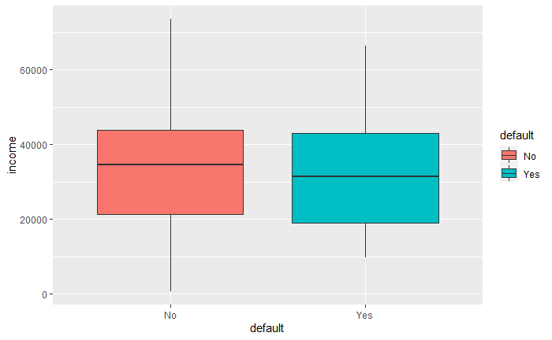

```r
ggplot(Default,aes(x=default,y=income,fill=default))+geom_boxplot()
```

## 2.4 Scatter plots

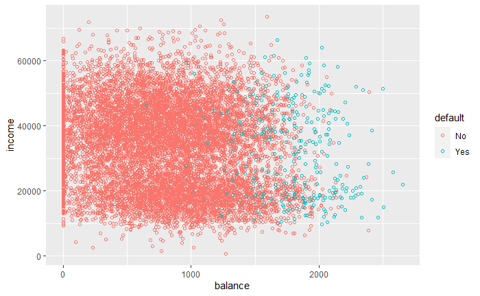

```r
Default %>%
  ggplot(aes(x=balance,y=income,color=default)) +
  geom_point(shape=1)
```

We need *rpart* package for Classification Trees. More on rpart : http://cran.r-project.org/web/packages/rpart/vignettes/longintro.pdf

`rpart.plot` is a package for visualizing classification tree models.

```r
library(rpart)
library(rpart.plot)
```

Let’s build a model.

```r
ct_model<-rpart(default~student+balance+income,           # model formula
                data=Default,                             # dataset
                method="class",                           # "class" indicates a classification tree model
                control=rpart.control(cp=0.03,maxdepth=4))   # tree control parameters.
```

Next, let’s visualize the tree model.

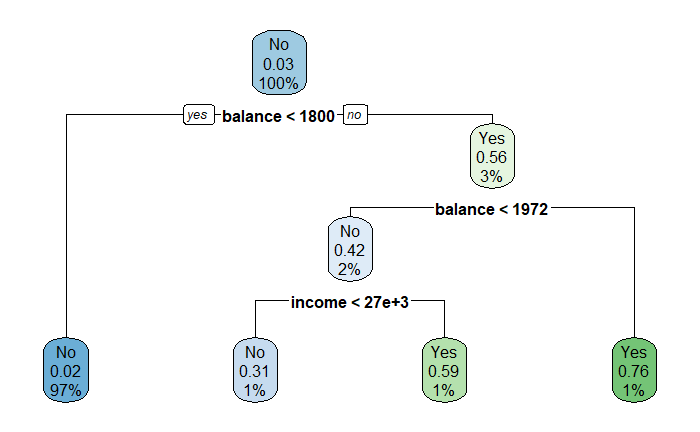

```r
rpart.plot(ct_model)   # tree plot
```

Here, I tried to visualize the classification tree model results on the scatterplot. It could be done, because the model used the two numeric variables.

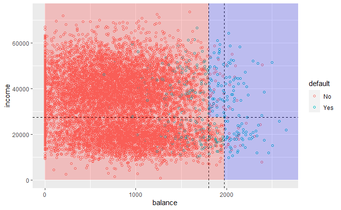

```r
Default %>%
  ggplot(aes(x=balance,y=income,color=default)) +
  geom_point(shape=1)+
  geom_vline(xintercept=1800.002,linetype="dashed")+
  geom_vline(xintercept=1971.915,linetype="dashed")+
  geom_hline(yintercept=27401.2,linetype="dashed")+
  annotate("rect",xmin=1800.002, xmax=1971.915, ymin=0, ymax=27401.2,fill="red",alpha=0.2)+
  annotate("rect",xmin=1971.915, xmax=Inf, ymin=0, ymax=Inf,fill="blue",alpha=0.2)+
  annotate("rect",xmin=0, xmax=1800.002, ymin=0, ymax=Inf,fill="red",alpha=0.2)+
  annotate("rect",xmin=1800.002, xmax=1971.915, ymin=27401.2, ymax=Inf,fill="blue",alpha=0.2)
```

```r
#print(ct_model)        # model results
```

```r
#summary(ct_model)      # model result details
```

Get the predicted value - class membership (yes or no) –> using a cut-off of 50%.

```r
ct_pred_class<-predict(ct_model,type="class") # class membership (yes or no)
head(ct_pred_class)
```

```
 1  2  3  4  5  6
No No No No No No
Levels: No Yes
```

```r
ct_pred<-predict(ct_model)  # get the predicted values - class probabilities (default)
head(ct_pred)
```

```
         No        Yes
1 0.9823929 0.01760708
2 0.9823929 0.01760708
3 0.9823929 0.01760708
4 0.9823929 0.01760708
5 0.9823929 0.01760708
6 0.9823929 0.01760708
```

Let’s create a new column in Default: save the predicted probability of default (yes) from the second column of dt_pred.

```r
Default$ct_pred_prob<-ct_pred[,2]
```

Alternatively, you can specify a certain cut-off value to assign class membership. You can set the cut-off at 30%, 50%, 80%, or whatever you want.

```r
Default$ct_pred_class<-ifelse(Default$ct_pred_prob>0.5,"Yes","No")
```

```r
head(Default)
```

| default | student | balance | income | ct_pred_prob | ct_pred_class |
| --- | --- | --- | --- | --- | --- |
| No | No | 729.5265 | 44361.625 | 0.01760708 | No |
| No | Yes | 817.1804 | 12106.135 | 0.01760708 | No |
| No | No | 1073.5492 | 31767.139 | 0.01760708 | No |
| No | No | 529.2506 | 35704.494 | 0.01760708 | No |
| No | No | 785.6559 | 38463.496 | 0.01760708 | No |
| No | Yes | 919.5885 | 7491.559 | 0.01760708 | No |

```r
Default[253,]     # get the information of 253th customer
```

| default | student | balance | income | ct_pred_prob | ct_pred_class |
| --- | --- | --- | --- | --- | --- |
| No | Yes | 488.8552 | 15159.49 | 0.01760708 | No |

```r
# show the customers whose predicted probability is greater than 70%
Default%>%
  filter(ct_pred_prob>0.7)
```

| default | student | balance | income | ct_pred_prob | ct_pred_class |
| --- | --- | --- | --- | --- | --- |
| Yes | Yes | 2205.800 | 14271.492 | 0.7627119 | Yes |
| No | Yes | 2022.675 | 18336.743 | 0.7627119 | Yes |
| Yes | No | 1991.649 | 42133.373 | 0.7627119 | Yes |
| Yes | No | 1981.452 | 28127.895 | 0.7627119 | Yes |
| No | Yes | 2004.728 | 27136.538 | 0.7627119 | Yes |
| No | No | 2113.019 | 34747.756 | 0.7627119 | Yes |
| Yes | No | 2033.192 | 44998.287 | 0.7627119 | Yes |
| Yes | No | 2024.105 | 51508.869 | 0.7627119 | Yes |
| No | Yes | 1994.049 | 14305.111 | 0.7627119 | Yes |
| Yes | No | 2499.017 | 51504.294 | 0.7627119 | Yes |

[output cut: 108 more lines]

```r
# sort customers by probability of default in descending order
Default%>%
  arrange(desc(ct_pred_prob))
```

| default | student | balance | income | ct_pred_prob | ct_pred_class |
| --- | --- | --- | --- | --- | --- |
| Yes | Yes | 2205.799521 | 14271.492 | 0.76271186 | Yes |
| No | Yes | 2022.674643 | 18336.743 | 0.76271186 | Yes |
| Yes | No | 1991.649120 | 42133.373 | 0.76271186 | Yes |
| Yes | No | 1981.451815 | 28127.895 | 0.76271186 | Yes |
| No | Yes | 2004.727568 | 27136.538 | 0.76271186 | Yes |
| No | No | 2113.019023 | 34747.756 | 0.76271186 | Yes |
| Yes | No | 2033.191790 | 44998.287 | 0.76271186 | Yes |
| Yes | No | 2024.105018 | 51508.869 | 0.76271186 | Yes |
| No | Yes | 1994.049188 | 14305.111 | 0.76271186 | Yes |
| Yes | No | 2499.016750 | 51504.294 | 0.76271186 | Yes |

[output cut: 990 more lines]

## 2.5 Random Forest

```r
set.seed(1)
#install.packages("randomForest")
library(randomForest)
rf_model<-randomForest(default~income+balance+student,              # model formula
                       data=Default,ntree=500, cutoff=c(0.5,0.5))
```

```r
#print(rf_model)
head(rf_model$votes)       # indicates the % of trees that voted for each class
```

```
         No         Yes
1 1.0000000 0.000000000
2 1.0000000 0.000000000
3 0.9946809 0.005319149
4 1.0000000 0.000000000
5 1.0000000 0.000000000
6 1.0000000 0.000000000
```

```r
head(rf_model$predicted)   # the class favored by more trees (i.e. majority vote wins)
```

```
 1  2  3  4  5  6
No No No No No No
Levels: No Yes
```

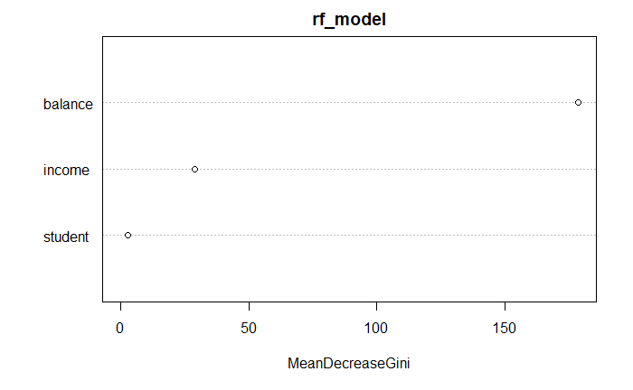

```r
varImpPlot(rf_model)  # importance of variables
```

```r
head(rf_model$vote)
```

```
         No         Yes
1 1.0000000 0.000000000
2 1.0000000 0.000000000
3 0.9946809 0.005319149
4 1.0000000 0.000000000
5 1.0000000 0.000000000
6 1.0000000 0.000000000
```

```r
Default$rf_vote<-predict(rf_model,type="prob")[,2]
head(Default)
```

| default | student | balance | income | ct_pred_prob | ct_pred_class | rf_vote |
| --- | --- | --- | --- | --- | --- | --- |
| No | No | 729.5265 | 44361.625 | 0.01760708 | No | 0.000000000 |
| No | Yes | 817.1804 | 12106.135 | 0.01760708 | No | 0.000000000 |
| No | No | 1073.5492 | 31767.139 | 0.01760708 | No | 0.005319149 |
| No | No | 529.2506 | 35704.494 | 0.01760708 | No | 0.000000000 |
| No | No | 785.6559 | 38463.496 | 0.01760708 | No | 0.000000000 |
| No | Yes | 919.5885 | 7491.559 | 0.01760708 | No | 0.000000000 |

## 2.6 Support Vector Machine (SVM)

```r
library(e1071)
model_svm<-svm(formula= default ~ balance+income+student, # model formula
               data=Default,                   # dataset
               kernel="linear",  # this is the form of the decision boundary. Let's start with a linear kernel.
               cost=0.1)        # there are paremeters that are used to tune the model
model_svm
```

```
Call:
svm(formula = default ~ balance + income + student, data = Default, kernel = "linear", cost = 0.1)


Parameters:
   SVM-Type:  C-classification
 SVM-Kernel:  linear
       cost:  0.1

Number of Support Vectors:  672
```

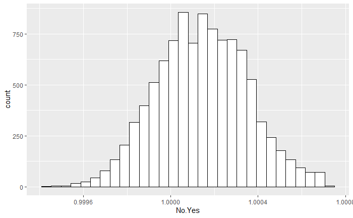

```r
dv<-data.frame(model_svm$decision.values)

ggplot(dv,aes(x=No.Yes)) +
  geom_histogram(colour="black",fill="white")
```

```r
head(model_svm$fitted)
```

```
 1  2  3  4  5  6
No No No No No No
Levels: No Yes
```

```r
table(model_svm$fitted)
```

```
   No   Yes
10000     0
```

```r
predicted_svm<-predict(model_svm,Default,decision.values = TRUE)
head(attr(predicted_svm, "decision.values"))
```

```
     No/Yes
1 1.0000632
2 1.0004151
3 0.9999982
4 1.0001708
5 1.0000694
6 1.0003995
```

```r
Default
```

| default | student | balance | income | ct_pred_prob | ct_pred_class | rf_vote |
| --- | --- | --- | --- | --- | --- | --- |
| No | No | 729.5264952 | 44361.625 | 0.01760708 | No | 0.000000000 |
| No | Yes | 817.1804066 | 12106.135 | 0.01760708 | No | 0.000000000 |
| No | No | 1073.5491640 | 31767.139 | 0.01760708 | No | 0.005319149 |
| No | No | 529.2506047 | 35704.494 | 0.01760708 | No | 0.000000000 |
| No | No | 785.6558829 | 38463.496 | 0.01760708 | No | 0.000000000 |
| No | Yes | 919.5885305 | 7491.559 | 0.01760708 | No | 0.000000000 |
| No | No | 825.5133305 | 24905.227 | 0.01760708 | No | 0.000000000 |
| No | Yes | 808.6675043 | 17600.451 | 0.01760708 | No | 0.000000000 |
| No | No | 1161.0578540 | 37468.529 | 0.01760708 | No | 0.000000000 |
| No | No | 0.0000000 | 29275.268 | 0.01760708 | No | 0.000000000 |

[output cut: 990 more lines]

```r
Default$svm_pred_class <- predict(model_svm, Default)
Default$svm_dv<-c(attr(predicted_svm, "decision.values"))

Default
```

| default | student | balance | income | ct_pred_prob | ct_pred_class | rf_vote | svm_pred_class | svm_dv |
| --- | --- | --- | --- | --- | --- | --- | --- | --- |
| No | No | 729.5264952 | 44361.625 | 0.01760708 | No | 0.000000000 | No | 1.0000632 |
| No | Yes | 817.1804066 | 12106.135 | 0.01760708 | No | 0.000000000 | No | 1.0004151 |
| No | No | 1073.5491640 | 31767.139 | 0.01760708 | No | 0.005319149 | No | 0.9999982 |
| No | No | 529.2506047 | 35704.494 | 0.01760708 | No | 0.000000000 | No | 1.0001708 |
| No | No | 785.6558829 | 38463.496 | 0.01760708 | No | 0.000000000 | No | 1.0000694 |
| No | Yes | 919.5885305 | 7491.559 | 0.01760708 | No | 0.000000000 | No | 1.0003995 |
| No | No | 825.5133305 | 24905.227 | 0.01760708 | No | 0.000000000 | No | 1.0001145 |
| No | Yes | 808.6675043 | 17600.451 | 0.01760708 | No | 0.000000000 | No | 1.0003941 |
| No | No | 1161.0578540 | 37468.529 | 0.01760708 | No | 0.000000000 | No | 0.9999428 |
| No | No | 0.0000000 | 29275.268 | 0.01760708 | No | 0.000000000 | No | 1.0003833 |

[output cut: 990 more lines]

## 2.7 Logistic Regression

```r
logit_model<-glm(default~student+balance+income,  # generalized linear models
                 family="binomial",               # specifying error distribution
                 data=Default)                    # dataset
summary(logit_model)
```

```
Call:
glm(formula = default ~ student + balance + income, family = "binomial",
    data = Default)

Deviance Residuals:
    Min       1Q   Median       3Q      Max
-2.4691  -0.1418  -0.0557  -0.0203   3.7383

Coefficients:
              Estimate Std. Error z value Pr(>|z|)
(Intercept) -1.087e+01  4.923e-01 -22.080  < 2e-16 ***
studentYes  -6.468e-01  2.363e-01  -2.738  0.00619 **
balance      5.737e-03  2.319e-04  24.738  < 2e-16 ***
income       3.033e-06  8.203e-06   0.370  0.71152
---
Signif. codes:  0 ‘***’ 0.001 ‘**’ 0.01 ‘*’ 0.05 ‘.’ 0.1 ‘ ’ 1

(Dispersion parameter for binomial family taken to be 1)

    Null deviance: 2920.6  on 9999  degrees of freedom
Residual deviance: 1571.5  on 9996  degrees of freedom
AIC: 1579.5

Number of Fisher Scoring iterations: 8
```

### 2.7.1 Use of the model to predict

```r
Default$log_odd<-predict(logit_model)                         # get predicted log odds (default)
Default$logit_pred_prob<-predict(logit_model,type="response") # get predicted probabilities
glimpse(Default)
```

```
Rows: 10,000
Columns: 11
$ default         <fct> No, No, No, No, No, No, No, No, No, No, No, No, No, No, No, No, No, No, No, No, No, No, No, No, No, No, No, No, No, No, No, No, No, No, No, No, No, No, No, No, No, No, No, No,~
$ student         <fct> No, Yes, No, No, No, Yes, No, Yes, No, No, Yes, Yes, No, No, No, No, No, Yes, No, No, No, No, No, No, No, No, No, No, No, Yes, No, Yes, Yes, No, Yes, Yes, No, No, No, No, No, ~
$ balance         <dbl> 729.5265, 817.1804, 1073.5492, 529.2506, 785.6559, 919.5885, 825.5133, 808.6675, 1161.0579, 0.0000, 0.0000, 1220.5838, 237.0451, 606.7423, 1112.9684, 286.2326, 0.0000, 527.540~
$ income          <dbl> 44361.625, 12106.135, 31767.139, 35704.494, 38463.496, 7491.559, 24905.227, 17600.451, 37468.529, 29275.268, 21871.073, 13268.562, 28251.695, 44994.556, 23810.174, 45042.413, ~
$ ct_pred_prob    <dbl> 0.01760708, 0.01760708, 0.01760708, 0.01760708, 0.01760708, 0.01760708, 0.01760708, 0.01760708, 0.01760708, 0.01760708, 0.01760708, 0.01760708, 0.01760708, 0.01760708, 0.01760~
$ ct_pred_class   <chr> "No", "No", "No", "No", "No", "No", "No", "No", "No", "No", "No", "No", "No", "No", "No", "No", "No", "No", "No", "No", "No", "No", "No", "No", "No", "No", "No", "No", "No", "~
$ rf_vote         <dbl> 0.000000000, 0.000000000, 0.005319149, 0.000000000, 0.000000000, 0.000000000, 0.000000000, 0.000000000, 0.000000000, 0.000000000, 0.011111111, 0.000000000, 0.000000000, 0.0000~
$ svm_pred_class  <fct> No, No, No, No, No, No, No, No, No, No, No, No, No, No, No, No, No, No, No, No, No, No, No, No, No, No, No, No, No, No, No, No, No, No, No, No, No, No, No, No, No, No, No, No,~
$ svm_dv          <dbl> 1.0000632, 1.0004151, 0.9999982, 1.0001708, 1.0000694, 1.0003995, 1.0001145, 1.0003941, 0.9999428, 1.0003833, 1.0006574, 1.0002694, 1.0003051, 1.0001033, 1.0000191, 1.0002148,~
$ log_odd         <dbl> -6.549544, -6.791338, -4.614261, -7.724689, -6.245449, -6.217871, -6.057935, -6.823506, -4.094972, -10.780240, -11.449476, -4.473686, -9.423535, -7.251976, -4.412269, -9.09043~
$ logit_pred_prob <dbl> 1.428724e-03, 1.122204e-03, 9.812272e-03, 4.415893e-04, 1.935506e-03, 1.989518e-03, 2.333767e-03, 1.086718e-03, 1.638333e-02, 2.080617e-05, 1.065494e-05, 1.127658e-02, 8.07933~
```

```r
Default%>%
  select("default","student","log_odd","logit_pred_prob")
```

| default | student | log_odd | logit_pred_prob |
| --- | --- | --- | --- |
| No | No | -6.54954384 | 1.428724e-03 |
| No | Yes | -6.79133795 | 1.122204e-03 |
| No | No | -4.61426074 | 9.812272e-03 |
| No | No | -7.72468852 | 4.415893e-04 |
| No | No | -6.24544900 | 1.935506e-03 |
| No | Yes | -6.21787130 | 1.989518e-03 |
| No | No | -6.05793487 | 2.333767e-03 |
| No | Yes | -6.82350552 | 1.086718e-03 |
| No | No | -4.09497180 | 1.638333e-02 |
| No | No | -10.78024013 | 2.080617e-05 |

[output cut: 990 more lines]

With the predicted probabilities, you can sort customers by the predicted probability of default in descending order.

```r
Default%>%
  arrange(desc(logit_pred_prob))%>%
  select(default, student, balance, income, ct_pred_prob, ct_pred_class,logit_pred_prob)
```

| default | student | balance | income | ct_pred_prob | ct_pred_class | logit_pred_prob |
| --- | --- | --- | --- | --- | --- | --- |
| Yes | Yes | 2654.323 | 21930.389 | 0.76271186 | Yes | 0.97762625 |
| Yes | No | 2499.017 | 51504.294 | 0.76271186 | Yes | 0.97398730 |
| Yes | Yes | 2578.469 | 25706.648 | 0.76271186 | Yes | 0.96622122 |
| Yes | No | 2413.319 | 38540.573 | 0.76271186 | Yes | 0.95655678 |
| No | No | 2391.008 | 50302.910 | 0.76271186 | Yes | 0.95255491 |
| Yes | Yes | 2502.685 | 14947.520 | 0.76271186 | Yes | 0.94715936 |
| Yes | No | 2343.798 | 51095.294 | 0.76271186 | Yes | 0.93884028 |
| Yes | Yes | 2461.507 | 11878.557 | 0.76271186 | Yes | 0.93343297 |
| Yes | No | 2288.408 | 52043.569 | 0.76271186 | Yes | 0.91806120 |
| Yes | Yes | 2415.317 | 17429.503 | 0.76271186 | Yes | 0.91625584 |

[output cut: 990 more lines]

And use a different cut-off for class prediction using `ifelse()`.

```r
Default$logit_pred_class<-ifelse(Default$logit_pred_prob>0.5,"Yes","No")
Default
```

| default | student | balance | income | ct_pred_prob | ct_pred_class | rf_vote | svm_pred_class | svm_dv | log_odd | logit_pred_prob | logit_pred_class |
| --- | --- | --- | --- | --- | --- | --- | --- | --- | --- | --- | --- |
| No | No | 729.5264952 | 44361.625 | 0.01760708 | No | 0.000000000 | No | 1.0000632 | -6.54954384 | 1.428724e-03 | No |
| No | Yes | 817.1804066 | 12106.135 | 0.01760708 | No | 0.000000000 | No | 1.0004151 | -6.79133795 | 1.122204e-03 | No |
| No | No | 1073.5491640 | 31767.139 | 0.01760708 | No | 0.005319149 | No | 0.9999982 | -4.61426074 | 9.812272e-03 | No |
| No | No | 529.2506047 | 35704.494 | 0.01760708 | No | 0.000000000 | No | 1.0001708 | -7.72468852 | 4.415893e-04 | No |
| No | No | 785.6558829 | 38463.496 | 0.01760708 | No | 0.000000000 | No | 1.0000694 | -6.24544900 | 1.935506e-03 | No |
| No | Yes | 919.5885305 | 7491.559 | 0.01760708 | No | 0.000000000 | No | 1.0003995 | -6.21787130 | 1.989518e-03 | No |
| No | No | 825.5133305 | 24905.227 | 0.01760708 | No | 0.000000000 | No | 1.0001145 | -6.05793487 | 2.333767e-03 | No |
| No | Yes | 808.6675043 | 17600.451 | 0.01760708 | No | 0.000000000 | No | 1.0003941 | -6.82350552 | 1.086718e-03 | No |
| No | No | 1161.0578540 | 37468.529 | 0.01760708 | No | 0.000000000 | No | 0.9999428 | -4.09497180 | 1.638333e-02 | No |
| No | No | 0.0000000 | 29275.268 | 0.01760708 | No | 0.000000000 | No | 1.0003833 | -10.78024013 | 2.080617e-05 | No |

[output cut: 990 more lines]

.

Let’s try to find the best set of parameters through model validation.

## 2.8 Classification Tree Model

### 2.8.1 train/test split

Let’s select 2,000 indices out of 10,000 (20% of dataset). Using these indices, we will create a test and a training dataset.

```r
set.seed(1)   # set a random seed
index <- sample(10000, 2000) # random selection of indices.
```

Check `index`. It contains 2,000 random numbers.

```r
index
```

[output not shown]

The following codes will select the data instances in the rows in `index` and save them as `test`. The rest will be saved as `training`.

```r
test <- Default[index,c("default","student","balance","income")]       # save 20% as a test dataset
#test1 <- Default[index, ]
training <-Default[-index,c("default","student","balance","income")]   # save the rest as a training set

test
```

| default | student | balance | income |
| --- | --- | --- | --- |
| No | No | 939.098502 | 45519.019 |
| No | Yes | 397.542488 | 22710.866 |
| Yes | No | 1511.610952 | 53506.945 |
| No | No | 301.319403 | 51539.952 |
| No | No | 878.446110 | 29561.783 |
| Yes | No | 1673.486349 | 49310.333 |
| No | No | 310.130224 | 37697.220 |
| No | No | 1272.053891 | 44895.593 |
| No | No | 887.201436 | 41641.454 |
| No | No | 230.868925 | 32798.783 |

[output cut: 990 more lines]

```r
training
```

| default | student | balance | income |
| --- | --- | --- | --- |
| No | No | 729.5264952 | 44361.625 |
| No | Yes | 817.1804066 | 12106.135 |
| No | No | 1073.5491640 | 31767.139 |
| No | No | 529.2506047 | 35704.494 |
| No | No | 785.6558829 | 38463.496 |
| No | Yes | 919.5885305 | 7491.559 |
| No | Yes | 808.6675043 | 17600.451 |
| No | No | 1161.0578540 | 37468.529 |
| No | No | 0.0000000 | 29275.268 |
| No | Yes | 0.0000000 | 21871.073 |

[output cut: 990 more lines]

```r
NA
```

Alternatively,

```r
test<-Default%>%
  filter(row_number() %in% index)%>%
  select("default","student","balance","income")

training<-Default%>%
  select("default","student","balance","income")%>%
  setdiff(test)
```

### 2.8.2 build a model with a training set

Build a model using the training set. This part is the same as before except we use `training` instead of the entire dataset.

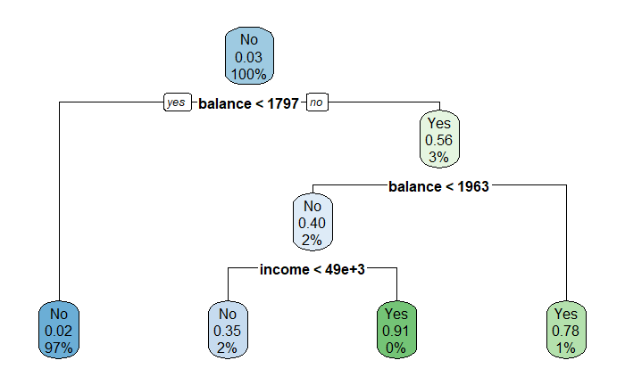

```r
training_model<-rpart(default~student+balance+income,
                      data=training,
                      method="class",
                      control=rpart.control(cp=0.03))

rpart.plot(training_model)
```

This model does not look much different from what we had. But we now have 20% of dataset that were not used when we built this model.

### 2.8.3 predicting probabilities/class labels for test data

Now, the model will be evaluated on a test data. For this, we apply the model to the test dataset and get the predicted values. It can be done by providing a dataset name with a model to `predict()` function.

```r
test$ct_pred_prob<-predict(training_model,test)[,2]
head(test)
```

| default | student | balance | income | ct_pred_prob |
| --- | --- | --- | --- | --- |
| No | No | 825.5133 | 24905.23 | 0.01737452 |
| No | No | 642.9997 | 41473.51 | 0.01737452 |
| No | No | 615.7043 | 39376.39 | 0.01737452 |
| No | No | 913.5872 | 46907.23 | 0.01737452 |
| No | Yes | 1499.7247 | 13190.65 | 0.01737452 |
| No | No | 351.4535 | 35087.49 | 0.01737452 |

```r
test$ct_pred_class<-predict(training_model,test,type="class")
test
```

| default | student | balance | income | ct_pred_prob | ct_pred_class |
| --- | --- | --- | --- | --- | --- |
| No | No | 825.513331 | 24905.227 | 0.01737452 | No |
| No | No | 642.999739 | 41473.512 | 0.01737452 | No |
| No | No | 615.704277 | 39376.395 | 0.01737452 | No |
| No | No | 913.587173 | 46907.225 | 0.01737452 | No |
| No | Yes | 1499.724657 | 13190.653 | 0.01737452 | No |
| No | No | 351.453472 | 35087.489 | 0.01737452 | No |
| No | No | 653.118400 | 39489.595 | 0.01737452 | No |
| No | No | 872.138680 | 41787.567 | 0.01737452 | No |
| No | Yes | 220.555608 | 16872.948 | 0.01737452 | No |
| No | No | 408.772914 | 54206.939 | 0.01737452 | No |

[output cut: 990 more lines]

Check the accuracy of the model by comparing the the actual values (default) and the predicted values (ct_pred_class).

```r
table(test$default==test$ct_pred_class)
```

```
FALSE  TRUE
   63  1937
```

```r
1947/2000
```

```
[1] 0.9735
```

```r
sum(predict(training_model, test, type="class")==test$default)/nrow(test)
```

```
[1] 0.9685
```

```r
sum(predict(training_model, training, type="class")==training$default)/nrow(training)
```

```
[1] 0.975
```

```r
###### holdout validation (Back to slide)********************
```

You may also want to check a confusion table.

```r
table(test$ct_pred_class,test$default, dnn=c("predicted","actual"))  # confusion table on test data
```

```
         actual
predicted   No  Yes
      No  1916   49
      Yes   14   21
```

### 2.8.4 k-fold Cross-validation

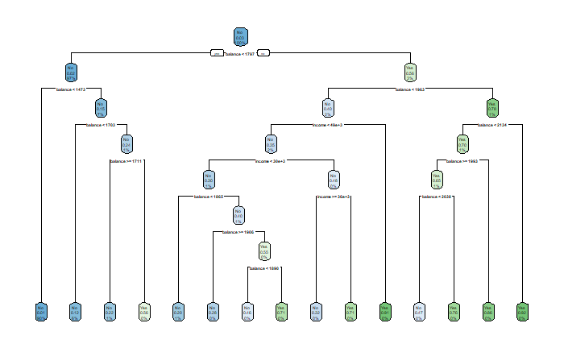

```r
set.seed(1)   # set a random seed
full_tree<-rpart(default~student+balance+income,
                     data=training,
                     method="class",
                     control=rpart.control(cp=0))        #complexity increases as cp value ~ zero

rpart.plot(full_tree)
```

`xerror` is cross-validated relative error rates, and `xstd` is its standard deviation.

```r
printcp(full_tree)   # xerror, xstd - cross validation results
```

```
Classification tree:
rpart(formula = default ~ student + balance + income, data = training,
    method = "class", control = rpart.control(cp = 0))

Variables actually used in tree construction:
[1] balance income

Root node error: 263/8000 = 0.032875

n= 8000

         CP nsplit rel error  xerror     xstd
1 0.1026616      0   1.00000 1.00000 0.060641
2 0.0342205      2   0.79468 0.84030 0.055739
3 0.0114068      3   0.76046 0.80608 0.054624
4 0.0038023      5   0.73764 0.82129 0.055122
5 0.0012674      8   0.72624 0.84791 0.055983
6 0.0000000     14   0.71863 0.93156 0.058597
```

Using `plotcp()`, you can check how the cross-validation error rate changes as the complexity of the model increases. In this chart, x-axis is model complexity, and y-axis is xerror rate (from cross-validation). The bars indicate standard deviation.

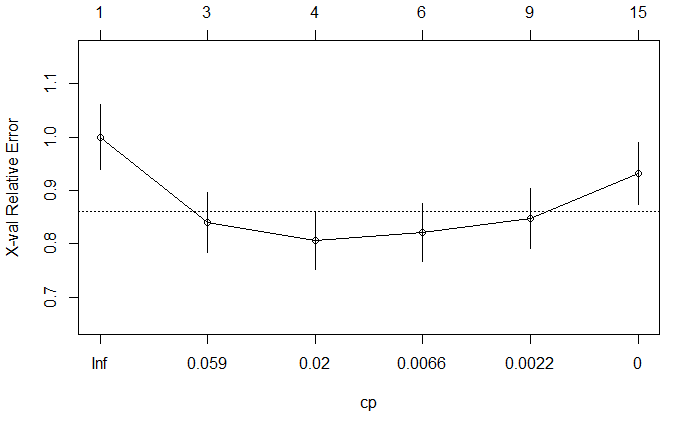

```r
plotcp(full_tree)
```

```r
min_xerror<-full_tree$cptable[which.min(full_tree$cptable[,"xerror"]),]
min_xerror
```

```
        CP     nsplit  rel error     xerror       xstd
0.01140684 3.00000000 0.76045627 0.80608365 0.05462358
```

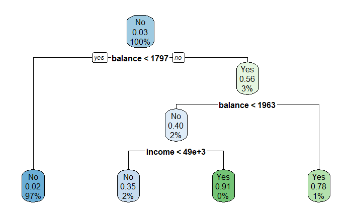

```r
# prune tree with minimum cp value
min_xerror_tree<-prune(full_tree, cp=min_xerror[1])
rpart.plot(min_xerror_tree)
```

Let’s consider mim_xerror_tree as the best pruned tree, and get the prediction.

```r
bp_tree<-min_xerror_tree
test$ct_bp_pred_prob<-predict(bp_tree,test)[,2]
test$ct_bp_pred_class=ifelse(test$ct_bp_pred_prob>0.5,"Yes","No")

head(test)
```

| default | student | balance | income | ct_pred_prob | ct_pred_class | ct_bp_pred_prob | ct_bp_pred_class |
| --- | --- | --- | --- | --- | --- | --- | --- |
| No | No | 825.5133 | 24905.23 | 0.01737452 | No | 0.01737452 | No |
| No | No | 642.9997 | 41473.51 | 0.01737452 | No | 0.01737452 | No |
| No | No | 615.7043 | 39376.39 | 0.01737452 | No | 0.01737452 | No |
| No | No | 913.5872 | 46907.23 | 0.01737452 | No | 0.01737452 | No |
| No | Yes | 1499.7247 | 13190.65 | 0.01737452 | No | 0.01737452 | No |
| No | No | 351.4535 | 35087.49 | 0.01737452 | No | 0.01737452 | No |

```r
table(test$ct_bp_pred_class!=test$default)  # error rate
```

```
FALSE  TRUE
 1937    63
```

```r
53/2000
```

```
[1] 0.0265
```

```r
1947/2000
```

```
[1] 0.9735
```

```r
sum(predict(bp_tree, test, type="class")!=test$default)/nrow(test)
```

```
[1] 0.0315
```

```r
table(test$ct_bp_pred_class,test$default, dnn=c("predicted","actual"))  # confusion table on test data
```

```
         actual
predicted   No  Yes
      No  1916   49
      Yes   14   21
```

## 2.9 Random Forest

### 2.9.1 hold-out validation vs. OOB errors

Following a similar process, we can validate the performance of a random forest model.

```r
set.seed(1)
rf_training_model<-randomForest(default~income+balance+student,              # model formula
                       data=training,          # use a training dataset for building a model
                       ntree=500,
                       cutoff=c(0.5,0.5),
                       mtry=2,                 # number of variables considered in each split (useful when lots of variables)
                       importance=TRUE)
rf_training_model
```

```
Call:
 randomForest(formula = default ~ income + balance + student,      data = training, ntree = 500, cutoff = c(0.5, 0.5), mtry = 2,      importance = TRUE)
               Type of random forest: classification
                     Number of trees: 500
No. of variables tried at each split: 2

        OOB estimate of  error rate: 2.96%
Confusion matrix:
      No Yes class.error
No  7671  66 0.008530438
Yes  171  92 0.650190114
```

```r
sum(predict(rf_training_model,test,type="class")!=test$default)/nrow(test)
```

```
[1] 0.033
```

### 2.9.2 hyperparameter tuning for Random Forest

The tuneRF() function has an argument, ntreeTry that defaults to 50 trees. Set nTreeTry = 500 to train a random forest model of the same size as you previously did. After tuning the forest, this function will plot model performance (OOB error) as a function of the mtry values that were evaluated.

```
mtry = 2  OOB error = 2.97%
Searching left ...
mtry = 1    OOB error = 2.75%
0.07563025 0.05
Searching right ...
mtry = 3    OOB error = 3.12%
-0.1363636 0.05
```

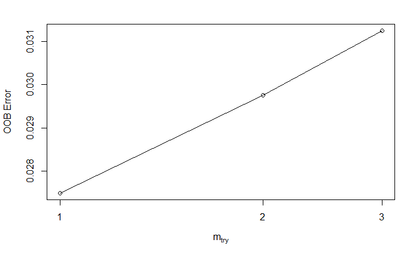

```r
# Execute the tuning process
set.seed(1)
res <- tuneRF(x = training%>%select(-default),
              y = training$default,mtryStart=2,
              ntreeTry = 500)
```

```r
rf_best_model<-randomForest(default~income+balance+student,              # model formula
                       data=training,          # use a training dataset for building a model
                       ntree=500,
                       cutoff=c(0.5,0.5),
                       mtry=1,
                       importance=TRUE)
rf_best_model
```

```
Call:
 randomForest(formula = default ~ income + balance + student,      data = training, ntree = 500, cutoff = c(0.5, 0.5), mtry = 1,      importance = TRUE)
               Type of random forest: classification
                     Number of trees: 500
No. of variables tried at each split: 1

        OOB estimate of  error rate: 2.7%
Confusion matrix:
      No Yes class.error
No  7711  26 0.003360476
Yes  190  73 0.722433460
```

```r
test$rf_pred_prob<-predict(rf_best_model,test,type="prob")[,2]   #use a test dataset for model evaluation
test$rf_pred_class<-predict(rf_best_model,test,type="class")
glimpse(test)
```

```
Rows: 2,000
Columns: 10
$ default          <fct> No, No, No, No, No, No, No, No, No, No, No, No, No, No, No, No, No, No, No, No, No, No, No, No, No, No, No, No, No, No, No, No, No, No, No, No, No, No, No, No, No, No, No, No~
$ student          <fct> No, No, No, No, Yes, No, No, No, Yes, No, Yes, Yes, No, No, No, No, No, Yes, Yes, Yes, Yes, No, No, No, No, No, No, Yes, No, Yes, No, No, No, Yes, No, No, Yes, Yes, No, No, N~
$ balance          <dbl> 825.5133, 642.9997, 615.7043, 913.5872, 1499.7247, 351.4535, 653.1184, 872.1387, 220.5556, 408.7729, 904.0403, 1294.4973, 1536.5946, 0.0000, 1480.6553, 0.0000, 196.4569, 948.~
$ income           <dbl> 24905.227, 41473.512, 39376.395, 46907.225, 13190.653, 35087.489, 39489.595, 41787.567, 16872.948, 54206.939, 16882.301, 10464.321, 48766.907, 32481.540, 36866.157, 43658.228~
$ ct_pred_prob     <dbl> 0.01737452, 0.01737452, 0.01737452, 0.01737452, 0.01737452, 0.01737452, 0.01737452, 0.01737452, 0.01737452, 0.01737452, 0.01737452, 0.01737452, 0.01737452, 0.01737452, 0.0173~
$ ct_pred_class    <fct> No, No, No, No, No, No, No, No, No, No, No, No, No, No, No, No, No, No, No, No, No, No, No, No, No, No, No, No, No, No, No, No, No, No, No, No, No, No, No, No, No, No, No, No~
$ ct_bp_pred_prob  <dbl> 0.01737452, 0.01737452, 0.01737452, 0.01737452, 0.01737452, 0.01737452, 0.01737452, 0.01737452, 0.01737452, 0.01737452, 0.01737452, 0.01737452, 0.01737452, 0.01737452, 0.0173~
$ ct_bp_pred_class <chr> "No", "No", "No", "No", "No", "No", "No", "No", "No", "No", "No", "No", "No", "No", "No", "No", "No", "No", "No", "No", "No", "No", "No", "No", "No", "No", "No", "No", "No", ~
$ rf_pred_prob     <dbl> 0.000, 0.000, 0.000, 0.000, 0.004, 0.000, 0.002, 0.000, 0.000, 0.000, 0.002, 0.004, 0.024, 0.000, 0.006, 0.000, 0.000, 0.000, 0.000, 0.000, 0.000, 0.000, 0.000, 0.000, 0.000,~
$ rf_pred_class    <fct> No, No, No, No, No, No, No, No, No, No, No, No, No, No, No, No, No, No, No, No, No, No, No, No, No, No, No, No, No, No, No, No, No, No, No, No, No, No, No, No, No, No, No, No~
```

```r
table(test$default==test$rf_pred_class)
```

```
FALSE  TRUE
   61  1939
```

```r
56/2000
```

```
[1] 0.028
```

```r
1944/2000
```

```
[1] 0.972
```

## 2.10 SVM

We can tune SVM models using `tune` function. Set a range of search values for the parameter. It builds an SVM model for each possible combination of parameter values and evaluate accuracy. It will return the parameter combination that yields the best accuracy.

```r
svm_tune <- tune(svm,                            # find a best set of parameters for the svm model
                 default~student+balance+income,
                 data = training,
                 kernel="radial",
                 ranges = list(cost = 10^(-5:0))) # specifying the ranges of parameters
                                                  # in the penalty function to be examined
                                                  # you may wish to increase the search space


print(svm_tune)                              # best parameters for the model
```

```
Parameter tuning of ‘svm’:

- sampling method: 10-fold cross validation

- best parameters:
```

|  | cost |
| --- | --- |
|  | 1 |

```
- best performance: 0.02825
```

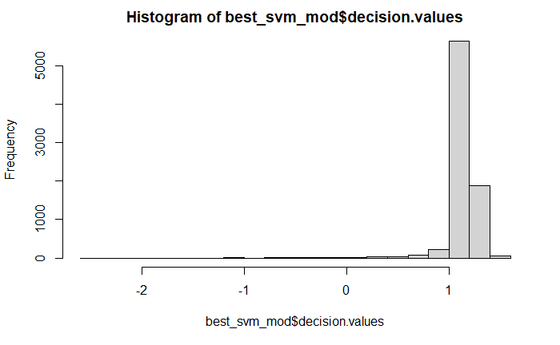

```r
best_svm_mod <- svm_tune$best.model          # best model is saved in best.model

hist(best_svm_mod$decision.values)
```

```r
#sum(best_svm_mod$decision.values < 0)
table(best_svm_mod$fitted)
```

```
  No  Yes
7937   63
```

```r
table(training$default==best_svm_mod$fitted)
```

```
FALSE  TRUE
  222  7778
```

```r
224/8000
```

```
[1] 0.028
```

```r
test$svm_pred_class <- predict(best_svm_mod, test) # save the predicted class by the svm model
test$svm_dv<-as.numeric(attr(predict(best_svm_mod, test, decision.values = TRUE),"decision.values"))
glimpse(test)
```

```
Rows: 2,000
Columns: 12
$ default          <fct> No, No, No, No, No, No, No, No, No, No, No, No, No, No, No, No, No, No, No, No, No, No, No, No, No, No, No, No, No, No, No, No, No, No, No, No, No, No, No, No, No, No, No, No~
$ student          <fct> No, No, No, No, Yes, No, No, No, Yes, No, Yes, Yes, No, No, No, No, No, Yes, Yes, Yes, Yes, No, No, No, No, No, No, Yes, No, Yes, No, No, No, Yes, No, No, Yes, Yes, No, No, N~
$ balance          <dbl> 825.5133, 642.9997, 615.7043, 913.5872, 1499.7247, 351.4535, 653.1184, 872.1387, 220.5556, 408.7729, 904.0403, 1294.4973, 1536.5946, 0.0000, 1480.6553, 0.0000, 196.4569, 948.~
$ income           <dbl> 24905.227, 41473.512, 39376.395, 46907.225, 13190.653, 35087.489, 39489.595, 41787.567, 16872.948, 54206.939, 16882.301, 10464.321, 48766.907, 32481.540, 36866.157, 43658.228~
$ ct_pred_prob     <dbl> 0.01737452, 0.01737452, 0.01737452, 0.01737452, 0.01737452, 0.01737452, 0.01737452, 0.01737452, 0.01737452, 0.01737452, 0.01737452, 0.01737452, 0.01737452, 0.01737452, 0.0173~
$ ct_pred_class    <fct> No, No, No, No, No, No, No, No, No, No, No, No, No, No, No, No, No, No, No, No, No, No, No, No, No, No, No, No, No, No, No, No, No, No, No, No, No, No, No, No, No, No, No, No~
$ ct_bp_pred_prob  <dbl> 0.01737452, 0.01737452, 0.01737452, 0.01737452, 0.01737452, 0.01737452, 0.01737452, 0.01737452, 0.01737452, 0.01737452, 0.01737452, 0.01737452, 0.01737452, 0.01737452, 0.0173~
$ ct_bp_pred_class <chr> "No", "No", "No", "No", "No", "No", "No", "No", "No", "No", "No", "No", "No", "No", "No", "No", "No", "No", "No", "No", "No", "No", "No", "No", "No", "No", "No", "No", "No", ~
$ rf_pred_prob     <dbl> 0.000, 0.000, 0.000, 0.000, 0.004, 0.000, 0.002, 0.000, 0.000, 0.000, 0.002, 0.004, 0.024, 0.000, 0.006, 0.000, 0.000, 0.000, 0.000, 0.000, 0.000, 0.000, 0.000, 0.000, 0.000,~
$ rf_pred_class    <fct> No, No, No, No, No, No, No, No, No, No, No, No, No, No, No, No, No, No, No, No, No, No, No, No, No, No, No, No, No, No, No, No, No, No, No, No, No, No, No, No, No, No, No, No~
$ svm_pred_class   <fct> No, No, No, No, No, No, No, No, No, No, No, No, No, No, No, No, No, No, No, No, No, No, No, No, No, No, No, No, No, No, No, No, No, No, No, No, No, No, No, No, No, No, No, No~
$ svm_dv           <dbl> 1.1349605, 1.1671835, 1.1957621, 1.0128594, 1.1050995, 1.2820775, 1.1741760, 1.0394192, 1.3316113, 1.1587966, 1.1072698, 1.0240360, 1.0956998, 1.0571845, 1.1086162, 1.0423542~
```

```r
table(test$default==test$svm_pred_class)
```

```
FALSE  TRUE
   60  1940
```

```r
56/2000
```

```
[1] 0.028
```

## 2.11 Logit regression

### 2.11.1 Hold-out validation

```r
logit_training_model<-glm(default~student+balance+income,family="binomial",data=training)
summary(logit_training_model)
```

```
Call:
glm(formula = default ~ student + balance + income, family = "binomial",
    data = training)

Deviance Residuals:
    Min       1Q   Median       3Q      Max
-2.1617  -0.1412  -0.0545  -0.0195   3.7829

Coefficients:
              Estimate Std. Error z value Pr(>|z|)
(Intercept) -1.072e+01  5.622e-01 -19.072   <2e-16 ***
studentYes  -6.461e-01  2.657e-01  -2.432    0.015 *
balance      5.784e-03  2.647e-04  21.854   <2e-16 ***
income      -4.445e-06  9.487e-06  -0.469    0.639
---
Signif. codes:  0 ‘***’ 0.001 ‘**’ 0.01 ‘*’ 0.05 ‘.’ 0.1 ‘ ’ 1

(Dispersion parameter for binomial family taken to be 1)

    Null deviance: 2313.6  on 7999  degrees of freedom
Residual deviance: 1247.6  on 7996  degrees of freedom
AIC: 1255.6

Number of Fisher Scoring iterations: 8
```

```r
test$logit_pred_prob<-predict(logit_training_model, test, type="response")    #get predicted probability
test$logit_pred_class<-ifelse(test$logit_pred_prob>0.5,"Yes","No")            #get predicted class
glimpse(test)
```

```
Rows: 2,000
Columns: 14
$ default          <fct> No, No, No, No, No, No, No, No, No, No, No, No, No, No, No, No, No, No, No, No, No, No, No, No, No, No, No, No, No, No, No, No, No, No, No, No, No, No, No, No, No, No, No, No~
$ student          <fct> No, No, No, No, Yes, No, No, No, Yes, No, Yes, Yes, No, No, No, No, No, Yes, Yes, Yes, Yes, No, No, No, No, No, No, Yes, No, Yes, No, No, No, Yes, No, No, Yes, Yes, No, No, N~
$ balance          <dbl> 825.5133, 642.9997, 615.7043, 913.5872, 1499.7247, 351.4535, 653.1184, 872.1387, 220.5556, 408.7729, 904.0403, 1294.4973, 1536.5946, 0.0000, 1480.6553, 0.0000, 196.4569, 948.~
$ income           <dbl> 24905.227, 41473.512, 39376.395, 46907.225, 13190.653, 35087.489, 39489.595, 41787.567, 16872.948, 54206.939, 16882.301, 10464.321, 48766.907, 32481.540, 36866.157, 43658.228~
$ ct_pred_prob     <dbl> 0.01737452, 0.01737452, 0.01737452, 0.01737452, 0.01737452, 0.01737452, 0.01737452, 0.01737452, 0.01737452, 0.01737452, 0.01737452, 0.01737452, 0.01737452, 0.01737452, 0.0173~
$ ct_pred_class    <fct> No, No, No, No, No, No, No, No, No, No, No, No, No, No, No, No, No, No, No, No, No, No, No, No, No, No, No, No, No, No, No, No, No, No, No, No, No, No, No, No, No, No, No, No~
$ ct_bp_pred_prob  <dbl> 0.01737452, 0.01737452, 0.01737452, 0.01737452, 0.01737452, 0.01737452, 0.01737452, 0.01737452, 0.01737452, 0.01737452, 0.01737452, 0.01737452, 0.01737452, 0.01737452, 0.0173~
$ ct_bp_pred_class <chr> "No", "No", "No", "No", "No", "No", "No", "No", "No", "No", "No", "No", "No", "No", "No", "No", "No", "No", "No", "No", "No", "No", "No", "No", "No", "No", "No", "No", "No", ~
$ rf_pred_prob     <dbl> 0.000, 0.000, 0.000, 0.000, 0.004, 0.000, 0.002, 0.000, 0.000, 0.000, 0.002, 0.004, 0.024, 0.000, 0.006, 0.000, 0.000, 0.000, 0.000, 0.000, 0.000, 0.000, 0.000, 0.000, 0.000,~
$ rf_pred_class    <fct> No, No, No, No, No, No, No, No, No, No, No, No, No, No, No, No, No, No, No, No, No, No, No, No, No, No, No, No, No, No, No, No, No, No, No, No, No, No, No, No, No, No, No, No~
$ svm_pred_class   <fct> No, No, No, No, No, No, No, No, No, No, No, No, No, No, No, No, No, No, No, No, No, No, No, No, No, No, No, No, No, No, No, No, No, No, No, No, No, No, No, No, No, No, No, No~
$ svm_dv           <dbl> 1.1349605, 1.1671835, 1.1957621, 1.0128594, 1.1050995, 1.2820775, 1.1741760, 1.0394192, 1.3316113, 1.1587966, 1.1072698, 1.0240360, 1.0956998, 1.0571845, 1.1086162, 1.0423542~
$ logit_pred_prob  <dbl> 2.332228e-03, 7.550376e-04, 6.508659e-04, 3.515907e-03, 5.993557e-02, 1.439296e-04, 8.075982e-04, 2.832000e-03, 3.836359e-05, 1.841700e-04, 1.995611e-03, 1.930890e-02, 1.1390~
$ logit_pred_class <chr> "No", "No", "No", "No", "No", "No", "No", "No", "No", "No", "No", "No", "No", "No", "No", "No", "No", "No", "No", "No", "No", "No", "No", "No", "No", "No", "No", "No", "No", ~
```

```r
table(test$default==test$logit_pred_class)
```

```
FALSE  TRUE
   57  1943
```

```r
57/2000
```

```
[1] 0.0285
```

```r
#sum(test$logit_pred_class!=test$default)/nrow(test)
```

### 2.11.2 step-wise regression

To improve the logit regression performance, it’s important to understand which variables should be included. Step-wise regression helps us select variables - assess model performance by adding variable and compare.

```r
# Specify a null model with no predictors
null_model <- glm(default~1, data = training, family = "binomial")

# Specify the full model using all of the potential predictors
full_model <- glm(default~student+balance+income, data = training, family = "binomial")

# Use a forward stepwise algorithm to build a parsimonious model
forward_model <- step(null_model, scope = list(lower = null_model, upper = full_model), direction = "forward")
```

```
Start:  AIC=2315.57
default ~ 1

          Df Deviance    AIC
+ balance  1   1259.5 1263.5
+ student  1   2292.9 2296.9
+ income   1   2299.7 2303.7
<none>         2313.6 2315.6

Step:  AIC=1263.54
default ~ balance

          Df Deviance    AIC
+ student  1   1247.8 1253.8
+ income   1   1253.5 1259.5
<none>         1259.5 1263.5

Step:  AIC=1253.84
default ~ balance + student

         Df Deviance    AIC
<none>        1247.8 1253.8
+ income  1   1247.6 1255.6
```

```r
summary(forward_model)
```

```
Call:
glm(formula = default ~ balance + student, family = "binomial",
    data = training)

Deviance Residuals:
    Min       1Q   Median       3Q      Max
-2.1738  -0.1413  -0.0546  -0.0195   3.7753

Coefficients:
              Estimate Std. Error z value Pr(>|z|)
(Intercept) -1.090e+01  4.220e-01 -25.826  < 2e-16 ***
balance      5.784e-03  2.647e-04  21.850  < 2e-16 ***
studentYes  -5.474e-01  1.630e-01  -3.359 0.000781 ***
---
Signif. codes:  0 ‘***’ 0.001 ‘**’ 0.01 ‘*’ 0.05 ‘.’ 0.1 ‘ ’ 1

(Dispersion parameter for binomial family taken to be 1)

    Null deviance: 2313.6  on 7999  degrees of freedom
Residual deviance: 1247.8  on 7997  degrees of freedom
AIC: 1253.8

Number of Fisher Scoring iterations: 8
```

```r
# Use a forward stepwise algorithm to build a parsimonious model
backward_model <- step(full_model, scope = list(lower = null_model, upper = full_model), direction = "backward")
```

```
Start:  AIC=1255.62
default ~ student + balance + income

          Df Deviance    AIC
- income   1   1247.8 1253.8
<none>         1247.6 1255.6
- student  1   1253.5 1259.5
- balance  1   2292.8 2298.8

Step:  AIC=1253.84
default ~ student + balance

          Df Deviance    AIC
<none>         1247.8 1253.8
- student  1   1259.5 1263.5
- balance  1   2292.9 2296.9
```

```r
summary(backward_model)
```

```
Call:
glm(formula = default ~ student + balance, family = "binomial",
    data = training)

Deviance Residuals:
    Min       1Q   Median       3Q      Max
-2.1738  -0.1413  -0.0546  -0.0195   3.7753

Coefficients:
              Estimate Std. Error z value Pr(>|z|)
(Intercept) -1.090e+01  4.220e-01 -25.826  < 2e-16 ***
studentYes  -5.474e-01  1.630e-01  -3.359 0.000781 ***
balance      5.784e-03  2.647e-04  21.850  < 2e-16 ***
---
Signif. codes:  0 ‘***’ 0.001 ‘**’ 0.01 ‘*’ 0.05 ‘.’ 0.1 ‘ ’ 1

(Dispersion parameter for binomial family taken to be 1)

    Null deviance: 2313.6  on 7999  degrees of freedom
Residual deviance: 1247.8  on 7997  degrees of freedom
AIC: 1253.8

Number of Fisher Scoring iterations: 8
```

```r
logit_best_model<-glm(default~student+balance,family="binomial",data=training)
summary(logit_best_model)
```

```
Call:
glm(formula = default ~ student + balance, family = "binomial",
    data = training)

Deviance Residuals:
    Min       1Q   Median       3Q      Max
-2.1738  -0.1413  -0.0546  -0.0195   3.7753

Coefficients:
              Estimate Std. Error z value Pr(>|z|)
(Intercept) -1.090e+01  4.220e-01 -25.826  < 2e-16 ***
studentYes  -5.474e-01  1.630e-01  -3.359 0.000781 ***
balance      5.784e-03  2.647e-04  21.850  < 2e-16 ***
---
Signif. codes:  0 ‘***’ 0.001 ‘**’ 0.01 ‘*’ 0.05 ‘.’ 0.1 ‘ ’ 1

(Dispersion parameter for binomial family taken to be 1)

    Null deviance: 2313.6  on 7999  degrees of freedom
Residual deviance: 1247.8  on 7997  degrees of freedom
AIC: 1253.8

Number of Fisher Scoring iterations: 8
```

```r
test$logit_pred_prob<-predict(logit_best_model,test,type="response")
test$logit_pred_class<-ifelse(test$logit_pred_prob>0.5,"Yes","No")
glimpse(test)
```

```
Rows: 2,000
Columns: 14
$ default          <fct> No, No, No, No, No, No, No, No, No, No, No, No, No, No, No, No, No, No, No, No, No, No, No, No, No, No, No, No, No, No, No, No, No, No, No, No, No, No, No, No, No, No, No, No~
$ student          <fct> No, No, No, No, Yes, No, No, No, Yes, No, Yes, Yes, No, No, No, No, No, Yes, Yes, Yes, Yes, No, No, No, No, No, No, Yes, No, Yes, No, No, No, Yes, No, No, Yes, Yes, No, No, N~
$ balance          <dbl> 825.5133, 642.9997, 615.7043, 913.5872, 1499.7247, 351.4535, 653.1184, 872.1387, 220.5556, 408.7729, 904.0403, 1294.4973, 1536.5946, 0.0000, 1480.6553, 0.0000, 196.4569, 948.~
$ income           <dbl> 24905.227, 41473.512, 39376.395, 46907.225, 13190.653, 35087.489, 39489.595, 41787.567, 16872.948, 54206.939, 16882.301, 10464.321, 48766.907, 32481.540, 36866.157, 43658.228~
$ ct_pred_prob     <dbl> 0.01737452, 0.01737452, 0.01737452, 0.01737452, 0.01737452, 0.01737452, 0.01737452, 0.01737452, 0.01737452, 0.01737452, 0.01737452, 0.01737452, 0.01737452, 0.01737452, 0.0173~
$ ct_pred_class    <fct> No, No, No, No, No, No, No, No, No, No, No, No, No, No, No, No, No, No, No, No, No, No, No, No, No, No, No, No, No, No, No, No, No, No, No, No, No, No, No, No, No, No, No, No~
$ ct_bp_pred_prob  <dbl> 0.01737452, 0.01737452, 0.01737452, 0.01737452, 0.01737452, 0.01737452, 0.01737452, 0.01737452, 0.01737452, 0.01737452, 0.01737452, 0.01737452, 0.01737452, 0.01737452, 0.0173~
$ ct_bp_pred_class <chr> "No", "No", "No", "No", "No", "No", "No", "No", "No", "No", "No", "No", "No", "No", "No", "No", "No", "No", "No", "No", "No", "No", "No", "No", "No", "No", "No", "No", "No", ~
$ rf_pred_prob     <dbl> 0.000, 0.000, 0.000, 0.000, 0.004, 0.000, 0.002, 0.000, 0.000, 0.000, 0.002, 0.004, 0.024, 0.000, 0.006, 0.000, 0.000, 0.000, 0.000, 0.000, 0.000, 0.000, 0.000, 0.000, 0.000,~
$ rf_pred_class    <fct> No, No, No, No, No, No, No, No, No, No, No, No, No, No, No, No, No, No, No, No, No, No, No, No, No, No, No, No, No, No, No, No, No, No, No, No, No, No, No, No, No, No, No, No~
$ svm_pred_class   <fct> No, No, No, No, No, No, No, No, No, No, No, No, No, No, No, No, No, No, No, No, No, No, No, No, No, No, No, No, No, No, No, No, No, No, No, No, No, No, No, No, No, No, No, No~
$ svm_dv           <dbl> 1.1349605, 1.1671835, 1.1957621, 1.0128594, 1.1050995, 1.2820775, 1.1741760, 1.0394192, 1.3316113, 1.1587966, 1.1072698, 1.0240360, 1.0956998, 1.0571845, 1.1086162, 1.0423542~
$ logit_pred_prob  <dbl> 2.184175e-03, 7.611338e-04, 6.500509e-04, 3.629822e-03, 5.883827e-02, 1.410627e-04, 8.069703e-04, 2.858310e-03, 3.827441e-05, 1.965014e-04, 1.990056e-03, 1.871933e-02, 1.1798~
$ logit_pred_class <chr> "No", "No", "No", "No", "No", "No", "No", "No", "No", "No", "No", "No", "No", "No", "No", "No", "No", "No", "No", "No", "No", "No", "No", "No", "No", "No", "No", "No", "No", ~
```

```r
table(test$default==test$logit_pred_class)
```

```
FALSE  TRUE
   57  1943
```

```r
57/2000
```

```
[1] 0.0285
```

## 2.12 Performance Visualization with ROC

```r
library(pROC)

ct_roc<-roc(test$default,test$ct_pred_prob,auc=TRUE)     #two arguments for roc function: true value, numeric result from model
rf_roc<-roc(test$default,test$rf_pred_prob,auc=TRUE)
logit_roc<-roc(test$default,test$logit_pred_prob,auc=TRUE)
svm_roc<-roc(test$default,test$svm_dv,auc=TRUE)
plot(ct_roc,print.auc=TRUE,col="blue")
plot(rf_roc,print.auc=TRUE,print.auc.y=.4,col="green", add=TRUE)
```

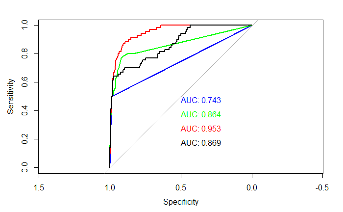

```r
plot(logit_roc,print.auc=TRUE,print.auc.y=.3, col="red",add=TRUE)
plot(svm_roc,print.auc=TRUE,print.auc.y=.2, col="black",add=TRUE)
```